# Work in progress: Bayesian Kernel Machine Regression

Bradley Bowen

Last Updated 26 March, 2025

## Introduction

Often the case with health data, mixtures may have non-linear relationships with the outcome variable, meaning that standard additive models may not be best suited. Working with highly correlated exposures and complex interaction effects with previous models could potentially lead to inconsistent estimates. In this tutorial, we will explore Bayesian Kernel Machine Regression (BKMR) which allows for increased flexibility for complex relationships between the predictor and outcome variables.

Kernel Machine Regression provides a more flexible approach by using a kernel. Kernels in regression are beneficial as they provide an estimation of the relationship between the predictors and outcome without knowing the form (linear, logistic, exponential, etc). This means that the kernel is a non-parametric technique. In order to determine the best fit between the predictor variables and outcome of interest, the kernel weights data points that are close in distance to outcome higher, and points that have a greater distance lower. This method allows the regression model to better fit the data and account for complex relationships between variables.

Additionally, the Bayesian Kernel Machine Regression integrates Kernel Machine Regression in a Bayesian framework, placing priors on model parameters, providing uncertainty quantification through the posterior, and allowing for flexibility such as hierarchical variable selection.

## Preparation

```r
library(tidyverse)
library(tidymodels)
library(ggcorrplot)
library(corrplot)
```

To illustrate how BKMR empowers modeling of highly correlated predictors, we will use the `nhanes` dataset where the variables are described in the file `nhanes-codebook.txt`. Load this data with the `load` function and specify the data file.

```r
load(file='nhanes1518.rda')
```

We first explore the URX predictors (i.e. the ones related to phthalates concentrations), subsetting the dataset to include only the same predictors in the weighted quantile sum module, and then filter out `NA` values:

```r
nhanes<-nhanes1518 |>
  select(BMXBMI,URXMHBP, URXMOH, URXMHP, URXMHH, URXMCOH, URXMHNC, URXMHH, URXECP, URXHIBP, URXMIB, RIDAGEYR)|>
  na.omit()|>
  mutate(BMXBMI = log(BMXBMI), RIDAGEYR = RIDAGEYR - 18)
```

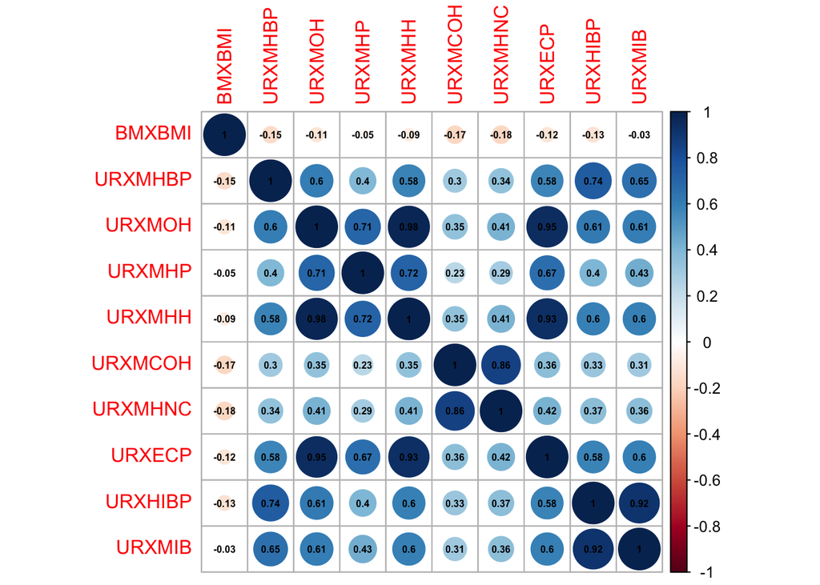

```r
corr_mat=cor(nhanes|>select(-RIDAGEYR),method="s")
corrplot(corr_mat, # colorful number
         addCoef.col = 1,    # Change font size of correlation coefficients
         number.cex = 0.5)
```

We also plot the distributions of our variables of interest involved in the model, and notice that the variables have a long tail in the original scale, which hints at log transformation which we will perform later on.

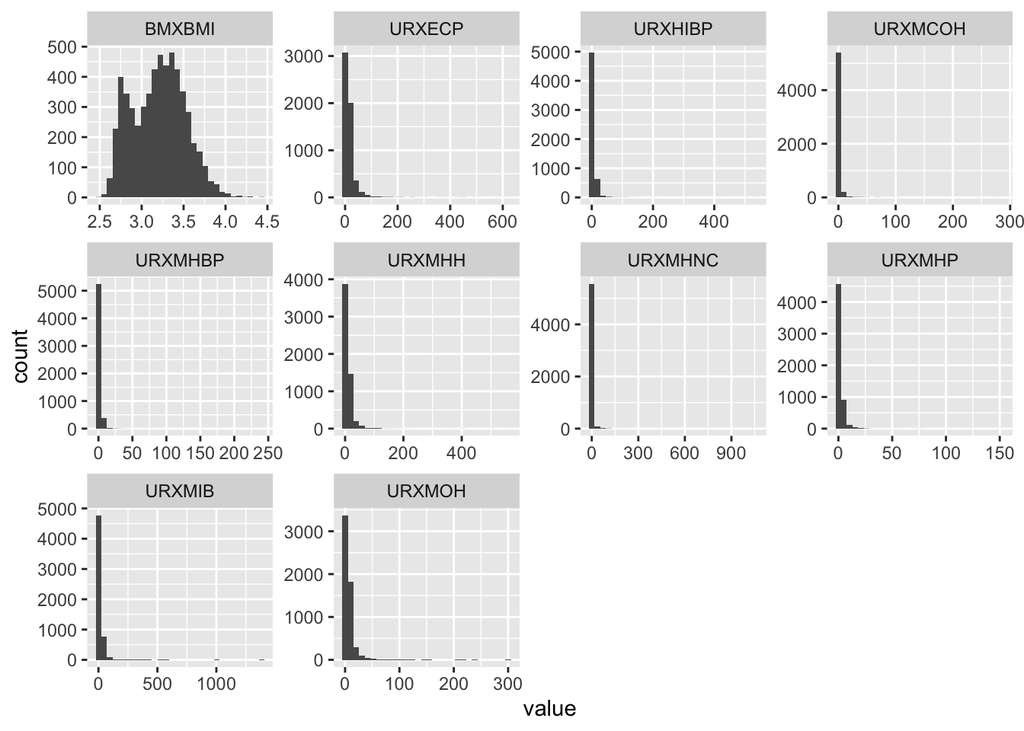

```r
df_long <- nhanes|>select(-RIDAGEYR) |> pivot_longer(everything())

# Plot histograms using ggplot
ggplot(df_long, aes(x = value)) +
  geom_histogram() +
  facet_wrap(~ name, scales = "free")
```

## Bayesian Kernel Machine Regression

Bayesian Kernel Machine Regression (BKMR) models the relationship between outcome and variables using two parts: a nonparametric function $h(\cdot)$ and linear function.

$$Y_i = h(\bf{Z}_i)+X_i\beta +
\epsilon_i,$$

where $\bf{Z}_i = (Z_{1i},\dots,Z_{ki})$ are chemical mixtures of observation $i$, $h(\cdot)$ is named predictor-response function, a nonparametric function capturing the nonlinear relationship between chemical mixtures and outcome, and $X_i$ representa other variables which may have linear relationship with outcome and $\beta$ corresponds to its coefficient. $\epsilon_i \overset{i.i.d.}{\sim} N(0,\sigma^2)$ is the error term.

The nonparametric function $h(\cdot)$ is highly flexible, and usually represented using kernel function:

$$h(\bf{Z}) = \sum_{i=1}^n K(Z_i,Z)
\alpha_i,$$

where $K(Z,Z')$ is a function measures the similarity of $Z$ and $Z'$, $\alpha_i$’s are coefficients. The outcome corresponding to $X$ are weighted by similarity of $Z$ to the data points $\{Z_i,i = 1,\dots,n\}$, data points that are more similar/ closer to $Z$ will plays more important role in outcome estimation. A common choice is a Gaussian kernel

$$K(Z,Z') =
exp\{-\sum_{k=1}^K(Z_k-Z_k')^2/\rho\}.$$

The BKMR can also allow for variable selection by slightly modifying the kernel:

$$K(Z,Z';r) =
exp\{-\sum_{k=1}^Kr_k(Z_k-Z_k')^2\},$$

where $r_k$ are non-negative values, with a “spike-and-slab” prior. If $r_k=0$, the variable $Z_k$ are excluded from the model. This variable selection method is similar to the frequentists’ LASSO shrinkage.

### Model Fitting

Similar to previous tutorials, we are interested in the research question: predicting log BMI using phthalate measurements from urine samples for individuals above 18 years of age. We assume the age has linear relationship to logBMI. For illustration, we randomly sample 10% from the dataset.

```r
set.seed(123)
nhanes = nhanes |> sample_frac(size = 0.1)
y <- nhanes$BMXBMI # bmi
Z <- nhanes |> select(-BMXBMI, -RIDAGEYR) # chemical mixtures
Z <- log(Z)
# group 1: URXMBP, URXMIB, URXMC1, URXMEP, URXMZP
# group 2: URXECP, URXMHH, URXMOH, URXMHP
X <- nhanes |> select(RIDAGEYR)
Z <- as.matrix(Z) |> scale()
X <- as.matrix(X)
```

To fit the BKMR model, we use the `kmbayes` function in R package `bkmr`.

```r
#install.packages("bkmr")
library(bkmr)
```

In the model:

- `y` is a vector of the response
- `Z` is the matrix containing chemical mixtures (variables with nonlinear relationship to outcome)
- `X` is the matrix containing other covariates with linear relationship to outcome
- `iter` number of iterations of the MCMC sampler
- `varsel`, whether to conduct variable selection on the predictors $Z$.
- `verbose`, printing the details during modeling fitting

In this example, we set `varsel = TRUE` to conduct variable selection while fitting the model.

```r
set.seed(1)
fitkm <- kmbayes(y = y, Z = Z, X = X, iter = 5000, varsel = TRUE, verbose = FALSE)
```

### Model Interpretation and Inference

#### Estimating Parameters

`ExtractEsts()` provides the summary statistics (mean, standard deviation, quantiles) of posterior samples of parameters $\beta$, $r_k$, and $\sigma^2$. We can use `q_2.5` and `q_97.5` (2.5% and 97.5% quantiles) to construct 95% credible interval.

```r
ExtractEsts(fitkm)
```

```
## $sigsq.eps
##                 mean          sd     q_2.5       q_25       q_50       q_75
## sigsq.eps 0.05759287 0.003491528 0.0511592 0.05518165 0.05746192 0.05984281
##               q_97.5
## sigsq.eps 0.06461115
##
## $beta
##             mean           sd       q_2.5        q_25        q_50        q_75
## beta 0.006593113 0.0004329955 0.005764133 0.006298141 0.006597041 0.006885753
##           q_97.5
## beta 0.007436542
##
## $lambda
##            mean       sd    q_2.5     q_25     q_50     q_75   q_97.5
## lambda 33.64641 12.98202 14.68944 24.16913 31.62367 40.48474 67.08331
##
## $r
##            mean          sd      q_2.5       q_25       q_50       q_75
## r1 0.0007126409 0.002991421 0.00000000 0.00000000 0.00000000 0.00000000
## r2 0.0004297215 0.002402648 0.00000000 0.00000000 0.00000000 0.00000000
## r3 0.0000000000 0.000000000 0.00000000 0.00000000 0.00000000 0.00000000
## r4 0.0000000000 0.000000000 0.00000000 0.00000000 0.00000000 0.00000000
## r5 0.0000000000 0.000000000 0.00000000 0.00000000 0.00000000 0.00000000
## r6 0.0000000000 0.000000000 0.00000000 0.00000000 0.00000000 0.00000000
## r7 0.0004761129 0.003591938 0.00000000 0.00000000 0.00000000 0.00000000
## r8 0.0145516694 0.004500822 0.01011490 0.01106806 0.01285694 0.01742771
## r9 0.0137789790 0.004082672 0.01027884 0.01203941 0.01277530 0.01413881
##        q_97.5
## r1 0.01375564
## r2 0.01011203
## r3 0.00000000
## r4 0.00000000
## r5 0.00000000
## r6 0.00000000
## r7 0.01087760
## r8 0.02660138
## r9 0.01982509
```

We can say for the selected sample, holding other variables constant, for each additional year of age, 95% of the posterior distribution for the percentage change in BMI is between 0.578% and 0.746%.

#### Estimating posterior inclusion probability

If we conduct variable selection (`varsel = TRUE`) while fitting the model, we can use `ExtractPIPs()` to extract the posterior inclusion probabilities(PIP). The PIPs represent the probability that a specific predictor is included in the model, providing a quantitative measure of the predictor’s importance.

For the selected sample, URXHIBP and URXMIB have PIP at 1, suggesting both URXHIBP and URXMIB have potential effects to BMI. URXMHBP, URXMOH, and URXECP have non-zero but small PIP, suggesting these three chemical mixtures may have some potential effect to BMI. For the chemical mixtures with PIP equal 0, they may not have potential effects to BMI when other chemical mixtures are presented.

```r
ExtractPIPs(fitkm)
```

```
##   variable    PIP
## 1  URXMHBP 0.0544
## 2   URXMOH 0.0340
## 3   URXMHP 0.0000
## 4   URXMHH 0.0000
## 5  URXMCOH 0.0000
## 6  URXMHNC 0.0000
## 7   URXECP 0.0256
## 8  URXHIBP 1.0000
## 9   URXMIB 1.0000
```

Alternatively, we can also use `summary()` to summarize BKMR model fits. Here we set `show_MH=FALSE` to avoid printing acceptance rates from Metropolis-Hastings algorithm. The acceptance rate can be used to evaluate convergence and mixing of MCMC sampler. We will discuss it in the MCMC Diagnostics section.

```r
summary(fitkm,show_MH = FALSE)
```

```
## Fitted object of class 'bkmrfit'
## Iterations: 5000
## Outcome family: gaussian
## Model fit on: 2025-03-26 22:52:43.671329
## Running time:  11.39405 mins
##
##
## Parameter estimates (based on iterations 2501-5000):
##        param     mean       sd    q_2.5   q_97.5
## 1       beta  0.00659  0.00043  0.00576  0.00744
## 2  sigsq.eps  0.05759  0.00349  0.05116  0.06461
## 3         r1  0.00071  0.00299  0.00000  0.01376
## 4         r2  0.00043  0.00240  0.00000  0.01011
## 5         r3  0.00000  0.00000  0.00000  0.00000
## 6         r4  0.00000  0.00000  0.00000  0.00000
## 7         r5  0.00000  0.00000  0.00000  0.00000
## 8         r6  0.00000  0.00000  0.00000  0.00000
## 9         r7  0.00048  0.00359  0.00000  0.01088
## 10        r8  0.01455  0.00450  0.01011  0.02660
## 11        r9  0.01378  0.00408  0.01028  0.01983
## 12    lambda 33.64641 12.98202 14.68944 67.08331
##
## Posterior inclusion probabilities:
##   variable    PIP
## 1  URXMHBP 0.0544
## 2   URXMOH 0.0340
## 3   URXMHP 0.0000
## 4   URXMHH 0.0000
## 5  URXMCOH 0.0000
## 6  URXMHNC 0.0000
## 7   URXECP 0.0256
## 8  URXHIBP 1.0000
## 9   URXMIB 1.0000
```

Notice, we cannot directly interpret parameters $r$. Instead, we can estimate $h(\cdot)$ to interpret the relationship between outcome and chemical mixtures

#### Estimating h

The function $h(\bf{Z})=h((Z_1,\dots,Z_k))$ is called predictor-response function, capturing how the predictors (chemical mixtures) influence the response (outcome variable (log(BMI))). This function allows us to account for nonlinear relationships as well as potential interactions.

Notice $h(\cdot)$ is a high-dimensional surface which cannot be visualized, and it takes a nonparametric form which is hard to interpret. Here we introduce three different ways to explore $h(\dot)$:

- Estimate h at a given value of predictors: $h(Z=z)$
- Uni/Bi-variable predictor-response function: holding other predictors constant, exploring relationship of one or two predictors (chemical mixtures) with the outcome, which is $h(Z_k = z_k|Z_{(-k)}=Z_{(-k),med})$ or $h(Z_k = z_k, Z_m = z_m|Z_{(-k,-m)}=Z_{(-k,-m),med})$.
- Overall risk summaries: calculating the overall effect of predictors by comparing $h(Z=z)/h(Z=Z_{med})$.

##### Estimate h at a given value of predictors

Notice the BKMR can be rewritten as follows:

$$y_i \sim
N(h_i+x_i^T\beta,\sigma^2)$$
$$\bf{h}=(h_1,\dots,h_n)^T \sim N(0,\tau
K)$$

where $K$ is a $n$ by $n$ kernel matrix, with $(i,j)$-element $K(z_i,z_j)=exp{-\sum_{k=1}^Kr_k(z_{ik}-z_{jk})^2}$.

Derived from this model, the posterior distribution of $h(\cdot)$ is normally distributed with mean $\mu_h(\theta)$ and variance $V_h(\theta)$, where $\theta=(\beta,r,\lambda)$ are parameters.

The `BKMR` package can estimate $h(\cdot)$ using three methods:

(1)`ComputePostmeanHnew(method = "approx")`. $h \sim N(\hat{\mu}_h,\hat{V}_h)$, where $\hat{\mu}_h$ and $\hat{V}_h$ are approximated by plugging in posterior mean of $\theta$: $\mu_h(\hat{\theta})$, $V_h(\hat{\theta})$.

(2)`ComputePostmeanHnew(method = "exact")`. $h \sim N(\hat{\mu}_h,\hat{V}_h)$, where $\hat{\mu}_h$ and $\hat{V}_h$ are $E(\mu_h(\theta))$ and $E(V_h(\theta))+Var(\mu_h(\theta))$ estimated by posterior samples.

(3)`SamplePred()`. $h \sim N(\mu_h,V_h)$. Instead of estimating posterior mean and variance, we directly sample $h$ given posterior samples of $\theta$.

The first approach is fast but only an approximation. The second and third approaches are exact methods that can provide unbiased estimates of posterior summaries, and the third approach can provide full posterior distribution. But these two exact methods take much longer time especially the third one. We recommend to use the third one for small dataset, the second one for moderate sized datasets and the first one for large dataset.

```r
# calculate the median of the Z's
med <- apply(Z, 2, median)
Znew <- matrix(med, nrow = 1)
# approach 1:
h_est1 <- ComputePostmeanHnew(fitkm, Znew = Znew, method = "approx")
# approach 2:
h_est2 <- ComputePostmeanHnew(fitkm, Znew = Znew, method = "exact")
# approach 3:
set.seed(1)
samps3 <- SamplePred(fitkm, Znew = Znew, Xnew = cbind(0))

compare <- data.frame(
  method = c(1:3),
  post_mean = c(h_est1$postmean, h_est2$postmean, mean(samps3)),
  post_sd = c(sqrt(h_est1$postvar), sqrt(h_est2$postvar), sd(samps3))
)

print(compare)
```

```
##   method post_mean    post_sd
## 1      1  3.106074 0.01287843
## 2      2  3.102730 0.01472242
## 3      3  3.103042 0.01406543
```

Both the second and third methods produced similar posterior means. However, the first “approximation” method differed slightly from the remaining approaches, and underestimates the standard deviation.

##### Uni/Bi-variable predictor-response function

`PredictorResponseUnivar()` captures relationship between $h$ and single predictor, while fixing other predictors at their median. As demonstrated in previous section, we can have three difference ways to estimate $h$. The default method is “approx”, we can switch to other methods by setting the argument `method =`.

We observe that for predictors with small PIP, the posterior means (blue line) of $h(\cdot)$ are horizontal line at 0, indicating that they do not have a large impact on the response.

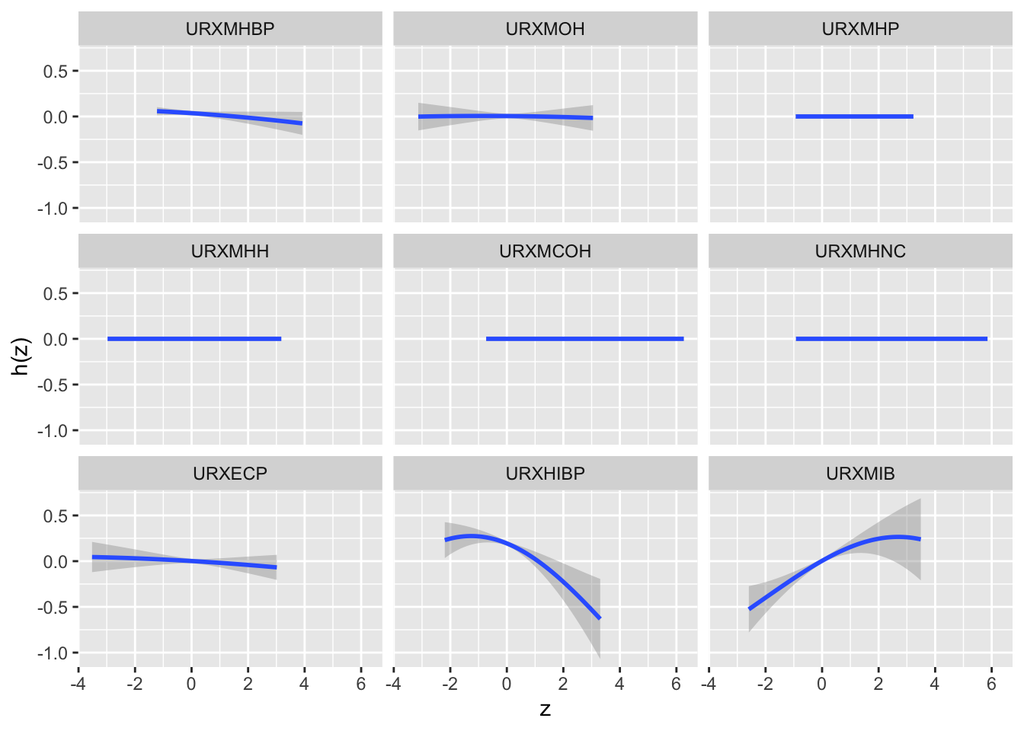

```r
pred.resp.univar <- PredictorResponseUnivar(fit = fitkm)
ggplot(pred.resp.univar, aes(z, est, ymin = est - 1.96*se, ymax = est + 1.96*se)) +
    geom_smooth(stat = "identity") +
    facet_wrap(~ variable) +
  ylab("h(z)")
```

To investigate relationship between $h$ and two predictors, we can plot the relationship between outcome and the first predictor given the second predictor at varying quantile levels, holding other predictors at a fixed quantile level (we use median by default). We need to apply `PredictorResponseBivar()` to obtain relationship between outcome and two predictors, then apply `PredictorResponseBivarLevels()` to obtain relationship between outcome and first predictor conditional on the second predictor.

Visualizing relationship between $h$ and two predictors can help us check the interactions between two predictors. Here we only select predictors with non-zero PIPs.

We observe that only for `URXHIBP` and `URXMIB`, there are clear difference among the lines in different colors, consistent with PIP results and the trend are similar to visualization for uni-variable predictor-response.

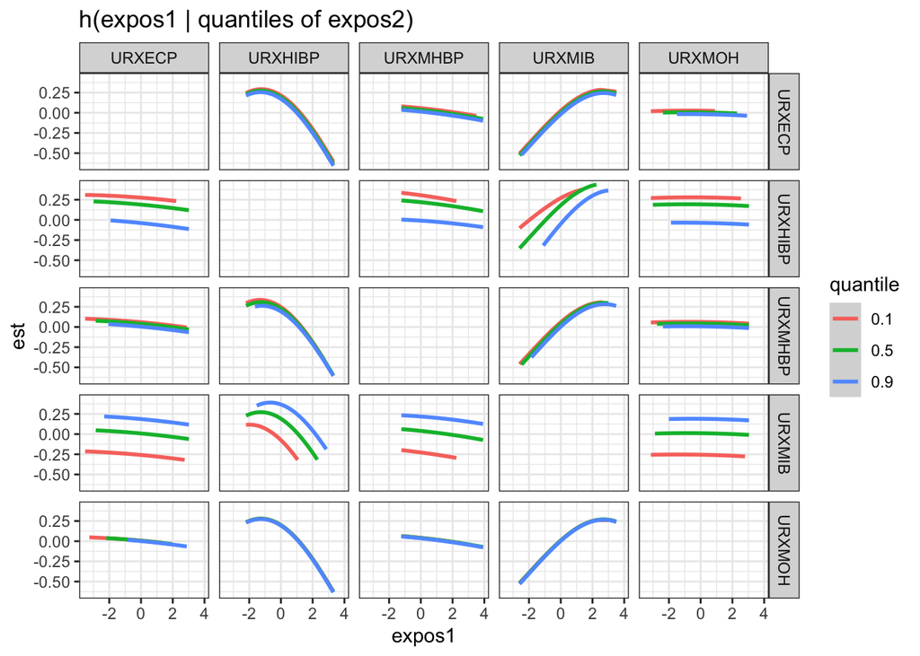

```r
pred.resp.bivar <- PredictorResponseBivar(fit = fitkm, min.plot.dist = 1)
pred.resp.bivar.levels <- PredictorResponseBivarLevels(
  pred.resp.df = pred.resp.bivar, Z = Z, qs = c(0.1, 0.5, 0.9))
var_nonzero = ExtractPIPs(fitkm)[ExtractPIPs(fitkm)[,2]>0,1]
pred.resp.bivar.levels = pred.resp.bivar.levels %>%
  filter(variable1%in%var_nonzero,variable2%in%var_nonzero)
ggplot(pred.resp.bivar.levels, aes(z1, est)) +
    geom_smooth(aes(col = quantile), stat = "identity") +
    facet_grid(variable2 ~ variable1) +
    ggtitle("h(expos1 | quantiles of expos2)") +
  xlab("expos1") +
  theme_bw()
```

##### Overall risk summaries

Summary statistics of the exposure-response function $h(z)$ can be also examined and visualized. Instead of considering the effect of one predictor conditional on other predictors, we can quantify the total effect of predictors, by comparing the $h(\cdot)$ when all predictors at their certain quantile levels relative to the median.

For example, we calculate $h(Z=Z_q)-h(Z=Z_{0.5})$, overall contributions of phthalate at their 0.2, 0.4, 0.6, 0.8 quantiles (`qs`) minus the response at their 0.5 quantiles. Notice, we can select reference quantile by specifying `q.fixed` and select the estimation method (default is `method = "approx"`).

We observe a decreasing trend, suggesting people with total pathalate at higher level tend to have lower BMI holding age constant. For people at the same age, we are 95% confident that people with total pathalate at a higher level (each pathalate is at 0.8 quantile) tend to have log BMI increase by -0.037 to 0.017 as compared to people with total pathalate at moderate level (each pathlate is at median).

```r
risks.overall <- OverallRiskSummaries(fit = fitkm, y = y, Z = Z, X = X,
                                      qs = seq(0.2, 0.8, by = 0.2),
                                      q.fixed = 0.5)
risks.overall %>%
  mutate(lowerCI = est - 1.96*sd, upperCI = est + 1.96*sd)
```

```
##   quantile          est          sd      lowerCI     upperCI
## 1      0.2  0.004784706 0.017205518 -0.028938109 0.038507522
## 2      0.4  0.001747921 0.004013293 -0.006118133 0.009613975
## 3      0.6  0.001436503 0.004407295 -0.007201796 0.010074802
## 4      0.8 -0.010267960 0.013665622 -0.037052579 0.016516658
```

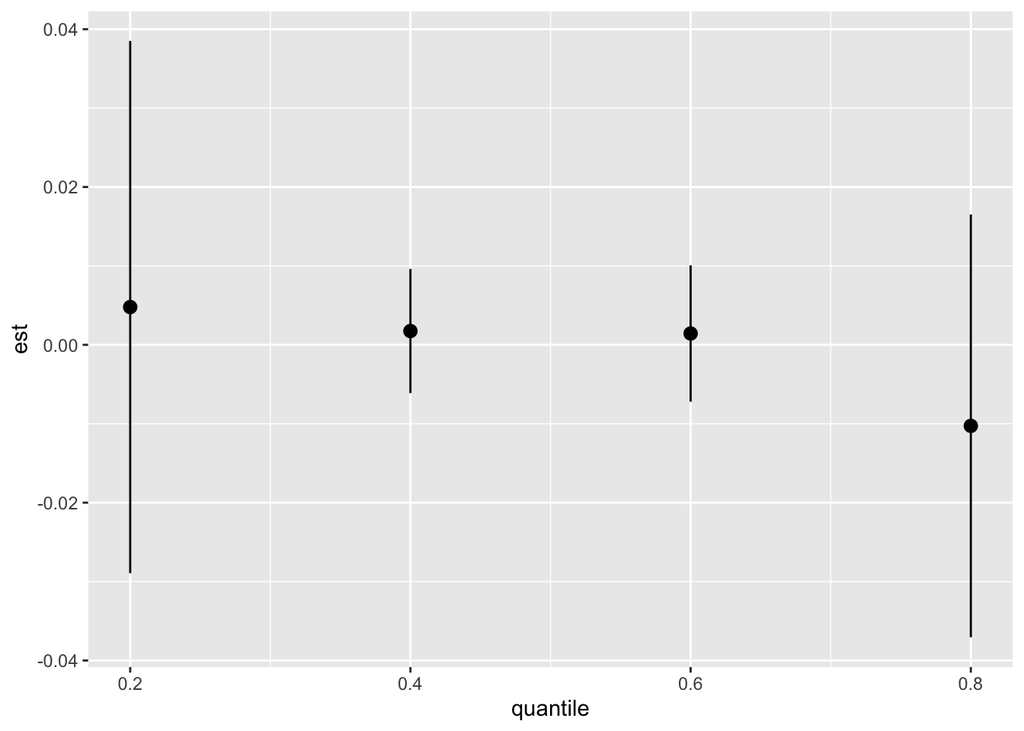

```r
ggplot(risks.overall, aes(quantile, est, ymin = est - 1.96*sd, ymax = est + 1.96*sd)) +
    geom_pointrange()
```

`SingVarRiskSummaries` focus on $h(z_{j,q2}-z_{j,q1}|Z_{(-j)}=Z_{(-j),0.5})$ the difference of $h()$ when a predictor is at its $q2$-quantile and $q1$-quantile, conditional on other predictors at a fixed quantile. `qs.diff` which indicates which quantile is being compared for the individual/target predictor, `q.fixed` argument indicates the quantiles of other predictors.

```r
risks.singvar <- SingVarRiskSummaries(fit = fitkm, y = y, Z = Z, X = X,
                                      qs.diff = c(0.25, 0.75),
                                      q.fixed = c(0.25, 0.50, 0.75),
                                      method = "exact")
risks.singvar
```

```
## # A tibble: 27 × 4
##    q.fixed variable      est      sd
##    <fct>   <fct>       <dbl>   <dbl>
##  1 0.25    URXMHBP  -0.00569 0.0248
##  2 0.25    URXMOH   -0.00138 0.00824
##  3 0.25    URXMHP    0       0
##  4 0.25    URXMHH    0       0
##  5 0.25    URXMCOH   0       0
##  6 0.25    URXMHNC   0       0
##  7 0.25    URXECP   -0.00111 0.00757
##  8 0.25    URXHIBP  -0.237   0.0505
##  9 0.25    URXMIB    0.167   0.0428
## 10 0.5     URXMHBP  -0.00219 0.0126
## # ℹ 17 more rows
```

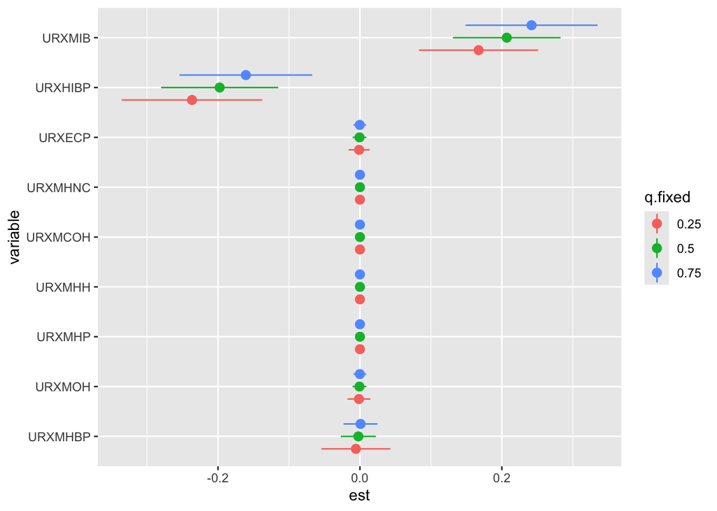

```r
ggplot(risks.singvar, aes(variable, est, ymin = est - 1.96*sd,
                          ymax = est + 1.96*sd, col = q.fixed)) +
    geom_pointrange(position = position_dodge(width = 0.75)) +
  coord_flip()
```

`SingVarIntSummaries` calculate $h(z_{j,q2}-z_{j,q1}|Z_{(-j)}=Z_{(-j),p2})-h(z_{j,q2}-z_{j,q1}|Z_{(-j)}=Z_{(-j),p1})$.

```r
risks.int <- SingVarIntSummaries(fit = fitkm, y = y, Z = Z, X = X,
                                 qs.diff = c(0.25, 0.75),
                                 qs.fixed = c(0.25, 0.75),
                                 method = "exact")
risks.int
```

```
## # A tibble: 9 × 3
##   variable      est      sd
##   <fct>       <dbl>   <dbl>
## 1 URXMHBP  0.00654  0.0290
## 2 URXMOH   0.00125  0.00825
## 3 URXMHP   0        0
## 4 URXMHH   0        0
## 5 URXMCOH  0        0
## 6 URXMHNC  0        0
## 7 URXECP   0.000871 0.00697
## 8 URXHIBP  0.0759   0.0531
## 9 URXMIB   0.0745   0.0478
```

### Model Prediction

We apply `SamplePred` to obtain posterior prediction samples. We can construct 95% credible interval by calculating 0.025 and 0.975 quantiles of posterior samples. Here we provide an example. For an individual with age 18 and fairly typical exposure values, his/her log BMI on average will between 3.07 and 3.13.

```r
med <- apply(Z, 2, median)
Znew <- matrix(med, nrow = 1)
y_pred <- SamplePred(fitkm, Znew = Znew, Xnew = 0)
quantile(y_pred,c(0.025,0.975))
```

```
##     2.5%    97.5%
## 3.070586 3.133297
```

### MCMC Diagnostics

Below, we can visualize the general trace of the Markov Chain Monte Carlo method for the samples. This graphs the $\beta$ parameter used in the BKMR model.

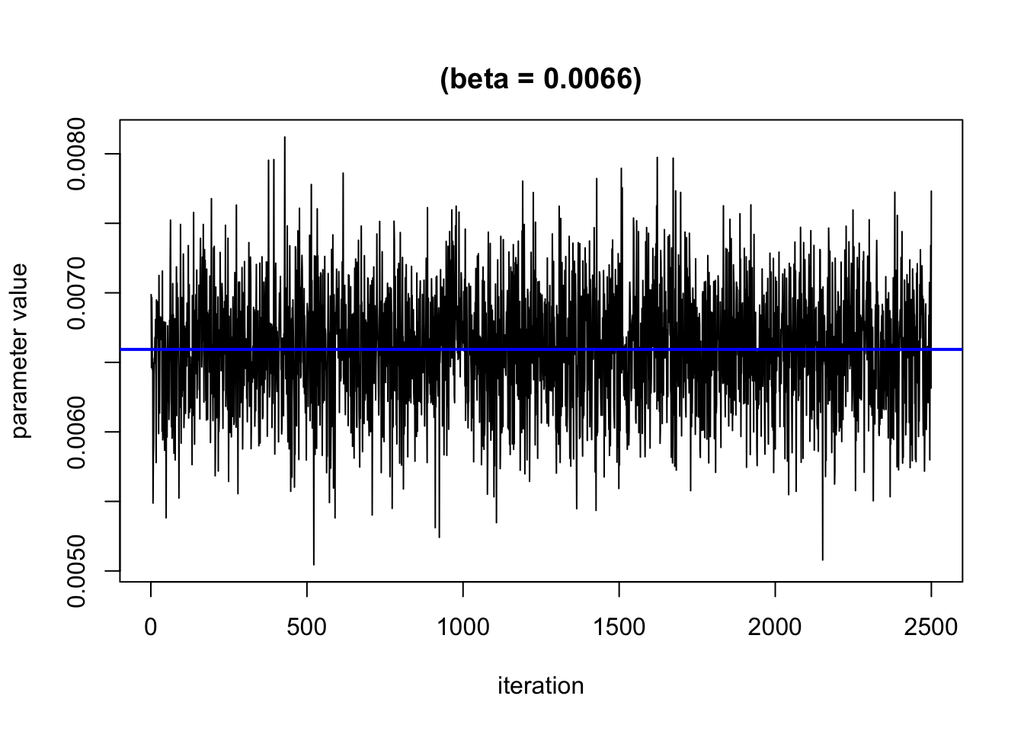

```r
TracePlot(fit = fitkm, par = "beta")
```

Examining the traceplot, it appears the chains generally show no noticeable patterns across iterations (no apparent wandering trends). Additionally, the samples thoroughly span over a consistent range of parameter values. Therefore, our model has convergence and overall favorable mixing.

## Miscellaneous

### Hierarchical Variable Selection

One of the appeals of BKMR regression is the ability to use hierarchical variable selection. This method assesses which variables are critical to the model by using grouping. Primarily, the chemical exposures are grouped, often by their relationships with other exposures or by using prior knowledge. Each exposure in the Z matrix can be assigned to a group by using `groups = c(1,1,2,2)` where the first two variables in Z are assigned to group 1, while the remaining variables are placed in group 2. If the variables are not manually grouped, there is an option for component wise selection where variables are evaluated on an individual basis (`varsel = TRUE`).

Here we use the previous example, but with three groups: (1) “URXMHBP”, “URXMOH”, “URXECP”; (2)“URXMHP”,“URXMHH”,“URXMCOH”,“URXMHNC”;(3)“URXHIBP”,“URXMIB”.

```r
set.seed(1)
fitkm_hier <- kmbayes(y = y, Z = Z, X = X, iter = 5000, varsel = TRUE,
                      groups = c(1,1,2,2,2,2,1,3,3), verbose = FALSE)
```

We can contrast the posterior inclusion probabilities from the two models:

```r
ExtractPIPs(fitkm)
```

```
##   variable    PIP
## 1  URXMHBP 0.0544
## 2   URXMOH 0.0340
## 3   URXMHP 0.0000
## 4   URXMHH 0.0000
## 5  URXMCOH 0.0000
## 6  URXMHNC 0.0000
## 7   URXECP 0.0256
## 8  URXHIBP 1.0000
## 9   URXMIB 1.0000
```

For grouped exposures, we can see the first group and third group have PIP greater than 0.5, suggesting including them in the model. Within the first group, URXMHBP is more likely associated with BMI. Within the third group, URXMIB is more likely associated with BMI.

```r
ExtractPIPs(fitkm_hier)
```

```
##   variable group groupPIP    condPIP
## 1  URXMHBP     1   0.5396 0.68346924
## 2   URXMOH     1   0.5396 0.16530764
## 3   URXMHP     2   0.0160 0.40000000
## 4   URXMHH     2   0.0160 0.12500000
## 5  URXMCOH     2   0.0160 0.47500000
## 6  URXMHNC     2   0.0160 0.00000000
## 7   URXECP     1   0.5396 0.15122313
## 8  URXHIBP     3   0.6852 0.06830123
## 9   URXMIB     3   0.6852 0.93169877
```

### Changing Tunning Parameters or Prior Distribution

Another feature of the BKMR package is that tuning parameters for the fitting algorithm can be manually adjusted. The model uses the Markov chain Monte Carlo method and also uses Gibbs steps for updating the parameters. The parameters can be accessed through the `control.params` argument. In the list of tuning methods, parameters including $\lambda$ (accessed by `lambda.jump`) can be adjusted which is the standard deviaion of the proposed distribution ($\lambda = \tau / \sigma^2$) where $\tau$ is the variance of the kernel matrix, adjusting the smoothness of the exposure-response. Additional adjustments include the standard deviation of the proposal distribution which can adjusted by `r.jump`. Parameters for the Monte Carlo Method can also be adjusted dependent on if the variable is not included and then included in the model or if the variable remains in the proposed model. If the exposure is initially not included to included in the model, the standard deviation can be specified by `r.jump1`. If the variable stays in the proposed model, the standard deviation is accessed through `r.jump2`. Finally, the mean can be modified if the variable is not included to included through `r.muprop`.

In addition to tuning parameters, the the prior distribution can be adjusted. The prior distribution can be specified by `r.prior` with options including include “gamma”, “invunif”, and “unif”. The mean and standard deviation for a gamma prior can be adjusted by `mu.lambda` and `sigma.lambda`. Additional adjustments for the gamma prior include $\sigma^2$ altered through `a.sigsq`, `b.sigsq`. For a beta prior, the shape parameters $\pi$ can be manipulated through `a.p0`, `b.p0` and should be used when `varsel = TRUE`.

Additional options can be found in the [github page](https://jenfb.github.io/bkmr/overview.html#changing_the_tuning_parameters_for_fitting_the_algorithm)

## References

- [manual](https://jenfb.github.io/bkmr/overview.html)
- [paper](https://ehjournal.biomedcentral.com/articles/10.1186/s12940-018-0413-y)
- [github](https://jenfb.github.io/bkmr/overview.html#changing_the_tuning_parameters_for_fitting_the_algorithm)